# Many_Analysts

Analyst: Sabrina McNew

7/10/2020

#### Project info: https://osf.io/34fzc/

#### Contact: sm983@cornell.edu

### Project goals

The goal of this project is to analyze a dataset of breeding blue tits in order to answer the question “does competition affect growth of tit nestlings?”

### Project approach outline (updated July 10, 2020)

Use linear models to test for sources of variation in tarsus length, nestling mass, and fledging success. Covariates include, treatment (increased, decreased, or control brood size), brood size, lay date, nestling sex, whether the nestling was transported into the nest or not. Random effects include: parent ids and geographical identifiers/structures of the nest, year.

Secondarily I tested whether the *variance* in tarsus length and width within a brood varies with clutch size or treatment.

### Methods: Analyses (as written for a manuscript)

#### Data verification

Data were checked for completeness and exploratory analyses were conducted following best-practices described by Zuur et al. (2010 Methods Ecol Evol). Briefly, I plotted key predictor and response variables to visually inspect their distribution. I looked to make sure they were uniformly or normally distributed (depending on common-sense expectation of the variable) and looked for outliers that would indicate mis-entry typos etc. Second, I looked for homogeneity in the variance of different treatment groups. For both tarsus length and mass there was slightly more variance in brood-increased treatment compared to control and brood-reduced treatments. However, overall the differences were minor. Finally, I checked for normality in continuously distributed response variables, such as tarsus. There were slight departures from normality in both the control and brood-increased treatment groups; however, these departures are common in ecological datasets and linear models are fairly robust to small departures in normality (Box 1976, J. Am. Stat Assoc.).

#### Analysis

##### Individual nestling growth and survival

I used linear mixed models (LMMs) and generalized linear mixed models (GLMMs) to test for differences among treatments in nestling size (day 14 tarsus length and mass) and fitness (fledging success and next-year survival). Tarsus length and mass were modeled with a Gaussian distribution (i.e. LMM); fledging success and next-year survival were modeled with a binomial distribution (i.e. logistic GLMM).

In addition to treatment, models included a suite of covariates that also could have influenced nestling size and fitness. Full models included the fixed effects of treatment, hatch nest lay date, whether the nestling was in its hatch nest or whether it had been experimentally moved to another nest, the clutch size of the nest from which the nestling hatched, and the molecular sex of the nestling. Non-significant factors were removed from the final model. Models also included the random effects of hatch year, the rearing nest id, rearing nestbox “nested” within nesting area, and the id of the rearing mother, rearing father, and genetic mother and genetic father.

I secondarily repeated these analyses by replacing the fixed effect of treatment with the rearing nest clutch size in models of nestling tarsus and mass. Because the brood size manipulation was designed to increase variation in brood size in a controlled and unbiased way, I used the post-manipulation brood size to more directly investigate the relationship between the number of nestlings in the nest and nestling growth.

##### Reproductive success by brood

Second I used linear mixed effects models to study the effects of treatment on brood-level fledging success and variance in nestling quality within the brood. If competition affects nestling growth, then nests in the brood-enlarged treatment will have more variance within the brood in nestling mass and tarsus length, and will have lower percent fledging success.  
Mass

As a preliminary control to test whether variance is positively correlated with brood size by chance, I simulated data for 130 nests ranging in clutch size from 4 to 16. I then simulated masses for each nestling assuming that masses were normally distributed and then calculated the variance in mass for each clutch. Finally, I used a linear model to test for a significant relationship between brood size and variance in mass for the brood. In 1000 simulations the p values were slightly right- skewed, but overall were fairly uniformly distributed. Thus, there does not seem to be a null expectation that variance should increase with brood size.

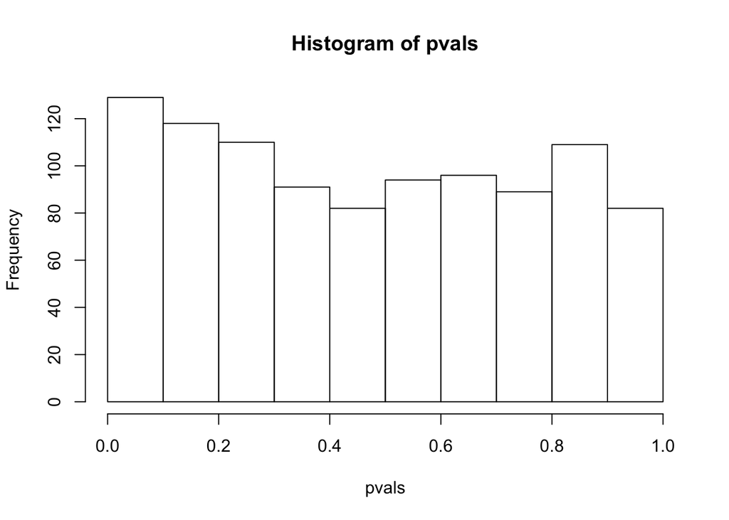

Then, I used LMMs to test for an effect of treatment on brood mass variance and brood tarsus length variance. Models additionally included the fixed effect of rearing nest lay date as well as the random effects of year, rearing nest parent ids, and rearing nest box nested within rearing nest area.

Finally, I tested for a difference in fledging success among treatments using a binomial GLMM where the response was the paired variable of the number of nestlings that fledged and the number that died for each nest. The model included the fixed effects of rearing nest lay date as well as the random effects of year, rearing nest parent ids, and rearing nest box nested within rearing nest area.

Several mixed-effects models reported the “boundary (singular) fit: see ?isSingular” warning. Singular fits can occur when the random effects structure is too complicated for the data. Being naive to the system, I included the full suite of random effects that could create structure in the data. However, someone more familiar with the system could potentially improve models by removing random effects that are unlikely to affect response variables.

### Results

#### Individual nestling success

```r
#Load data
tit <- read.csv("data/blue_tit_data_updated_2020-04-18.csv")

# Turn these integer columns into factors
tit <- tit %>%  mutate_at(vars(hatch_year,
                        Extra.pair_paternity,
                        rear_nest_trt,
                        home_or_away,
                        chick_sex_molec,
                        chick_survival_to_first_breed_season

), as.factor)
tit$rear_nest_trt <- relevel(tit$rear_nest_trt, ref = "7")
```

Nestling mass at day 14 was significantly lower in the brood-increased treatment compared to control nestlings (estimated difference in means: -0.91g; 95%CI -1.18 - -0.64g); p < 0.001; Table 1). However, nestling mass in the brood-reduced treatment was not significantly different from controls (p = 0.69; Table 1). Hatch date of the nest, whether the nestling was reared in its natal brood or was transplanted, hatch nest clutch size, and nestling sex all also had significant effects on nestling mass (Table 1).

```r
# Table 1. Code and results for nestling mass model
mod1 <-(
  lmer(
    day_14_weight ~
      rear_nest_trt +
      hatch_nest_LD +
      home_or_away +
      hatch_nest_CS +
      chick_sex_molec +
      (1 | hatch_year) + (1 | rear_nest_breed_ID) +
      (1 | rear_mom_Ring) + (1 | rear_dad_Ring) +
      (1 | hatch_mom_Ring) + (1 | genetic_dad_ring_.WP_or_EP.) +
      (1 | rear_area / rear_Box),
    data = tit
  )
)
tab_model(mod1)
```

|  | day_14_weight |  |  |
| --- | --- | --- | --- |
| Predictors | Estimates | CI | p |
| (Intercept) | 12.17 | 11.17 – 13.17 | **<0.001** |
| rear_nest_trt [5] | -0.91 | -1.18 – -0.64 | **<0.001** |
| rear_nest_trt [6] | 0.06 | -0.22 – 0.33 | 0.694 |
| hatch_nest_LD | -0.03 | -0.05 – -0.01 | **0.001** |
| home_or_away [2] | 0.15 | 0.07 – 0.22 | **<0.001** |
| hatch_nest_CS | -0.11 | -0.17 – -0.06 | **<0.001** |
| chick_sex_molec [2] | 0.50 | 0.44 – 0.57 | **<0.001** |
| Random Effects |  |  |  |
| σ<sup>2</sup> | 0.44 |  |  |
| τ<sub>00</sub> <sub>rear_nest_breed_ID</sub> | 0.10 |  |  |
| τ<sub>00</sub> <sub>genetic_dad_ring_.WP_or_EP.</sub> | 0.06 |  |  |
| τ<sub>00</sub> <sub>hatch_mom_Ring</sub> | 0.07 |  |  |
| τ<sub>00</sub> <sub>rear_Box:rear_area</sub> | 0.14 |  |  |
| τ<sub>00</sub> <sub>rear_mom_Ring</sub> | 0.00 |  |  |
| τ<sub>00</sub> <sub>rear_dad_Ring</sub> | 0.22 |  |  |
| τ<sub>00</sub> <sub>rear_area</sub> | 0.03 |  |  |
| τ<sub>00</sub> <sub>hatch_year</sub> | 0.18 |  |  |
| ICC | 0.65 |  |  |
| N <sub>hatch_year</sub> | 3 |  |  |
| N <sub>rear_nest_breed_ID</sub> | 269 |  |  |
| N <sub>rear_mom_Ring</sub> | 241 |  |  |
| N <sub>rear_dad_Ring</sub> | 240 |  |  |
| N <sub>hatch_mom_Ring</sub> | 251 |  |  |
| N <sub>genetic_dad_ring_.WP_or_EP.</sub> | 261 |  |  |
| N <sub>rear_Box</sub> | 243 |  |  |
| N <sub>rear_area</sub> | 9 |  |  |
| Observations | 1936 |  |  |
| Marginal R<sup>2</sup> / Conditional R<sup>2</sup> | 0.221 / 0.725 |  |  |

Nestling tarsus length at day 14 was also significantly smaller in enlarged broods, compared to controls, though again there was no difference between reduced broods and controls (Table 2). Hatch nest lay date and hatch nest clutch size had no significant effect on tarsus length; however, transplanted nestlings and male nestlings had significantly longer tarsi than nestlings reared in their hatch nest and female nestlings (Table 2).

```
## boundary (singular) fit: see ?isSingular
```

Table 2.

|  | day_14_tarsus_length |  |  |
| --- | --- | --- | --- |
| Predictors | Estimates | CI | p |
| (Intercept) | 16.50 | 16.34 – 16.65 | **<0.001** |
| rear_nest_trt [5] | -0.20 | -0.34 – -0.06 | **0.004** |
| rear_nest_trt [6] | 0.13 | -0.01 – 0.27 | 0.076 |
| home_or_away [2] | 0.06 | 0.01 – 0.11 | **0.014** |
| chick_sex_molec [2] | 0.48 | 0.43 – 0.52 | **<0.001** |
| Random Effects |  |  |  |
| σ<sup>2</sup> | 0.20 |  |  |
| τ<sub>00</sub> <sub>rear_nest_breed_ID</sub> | 0.03 |  |  |
| τ<sub>00</sub> <sub>genetic_dad_ring_.WP_or_EP.</sub> | 0.02 |  |  |
| τ<sub>00</sub> <sub>hatch_Box:hatch_Area</sub> | 0.00 |  |  |
| τ<sub>00</sub> <sub>hatch_mom_Ring</sub> | 0.08 |  |  |
| τ<sub>00</sub> <sub>rear_mom_Ring</sub> | 0.02 |  |  |
| τ<sub>00</sub> <sub>rear_dad_Ring</sub> | 0.00 |  |  |
| τ<sub>00</sub> <sub>hatch_Area</sub> | 0.00 |  |  |
| τ<sub>00</sub> <sub>hatch_year</sub> | 0.01 |  |  |
| ICC | 0.45 |  |  |
| N <sub>rear_mom_Ring</sub> | 242 |  |  |
| N <sub>rear_dad_Ring</sub> | 241 |  |  |
| N <sub>hatch_mom_Ring</sub> | 253 |  |  |
| N <sub>genetic_dad_ring_.WP_or_EP.</sub> | 263 |  |  |
| N <sub>hatch_year</sub> | 3 |  |  |
| N <sub>rear_nest_breed_ID</sub> | 270 |  |  |
| N <sub>hatch_Box</sub> | 253 |  |  |
| N <sub>hatch_Area</sub> | 9 |  |  |
| Observations | 1950 |  |  |
| Marginal R<sup>2</sup> / Conditional R<sup>2</sup> | 0.178 / 0.547 |  |  |

Nestlings were slightly more likely to survive to their first breeding season in the brood-reduced treatment (Odds ratio estimate: 1.70, 95%CI 1.00 - 2.91; p = 0.05, Table 3). However, there was no difference in between enlarged broods and controls.

Table 3.

|  | chick_survival_to_first_breed_season |  |  |
| --- | --- | --- | --- |
| Predictors | Odds Ratios | CI | p |
| (Intercept) | 0.10 | 0.05 – 0.21 | **<0.001** |
| rear_nest_trt [5] | 0.90 | 0.52 – 1.54 | 0.702 |
| rear_nest_trt [6] | 1.70 | 1.00 – 2.91 | 0.051 |
| hatch_nest_LD | 0.94 | 0.92 – 0.97 | **<0.001** |
| Random Effects |  |  |  |
| σ<sup>2</sup> | 3.29 |  |  |
| τ<sub>00</sub> <sub>rear_nest_breed_ID</sub> | 0.32 |  |  |
| τ<sub>00</sub> <sub>genetic_dad_ring_.WP_or_EP.</sub> | 0.00 |  |  |
| τ<sub>00</sub> <sub>hatch_mom_Ring</sub> | 0.00 |  |  |
| τ<sub>00</sub> <sub>hatch_Box:hatch_Area</sub> | 0.00 |  |  |
| τ<sub>00</sub> <sub>rear_mom_Ring</sub> | 0.00 |  |  |
| τ<sub>00</sub> <sub>rear_dad_Ring</sub> | 0.00 |  |  |
| τ<sub>00</sub> <sub>hatch_Area</sub> | 0.02 |  |  |
| τ<sub>00</sub> <sub>hatch_year</sub> | 0.04 |  |  |
| ICC | 0.10 |  |  |
| N <sub>rear_mom_Ring</sub> | 322 |  |  |
| N <sub>rear_dad_Ring</sub> | 319 |  |  |
| N <sub>hatch_mom_Ring</sub> | 334 |  |  |
| N <sub>genetic_dad_ring_.WP_or_EP.</sub> | 341 |  |  |
| N <sub>hatch_year</sub> | 3 |  |  |
| N <sub>rear_nest_breed_ID</sub> | 359 |  |  |
| N <sub>hatch_Box</sub> | 326 |  |  |
| N <sub>hatch_Area</sub> | 9 |  |  |
| Observations | 2695 |  |  |
| Marginal R<sup>2</sup> / Conditional R<sup>2</sup> | 0.082 / 0.177 |  |  |

#### Using brood size as a predictor

Models using the number of nestlings post-manipulation revealed similar effects on day 14 nestling mass and tarsus size. The number of nestlings in the brood was negatively associated with day 14 weight (Table 4).

Table 4.

|  | day_14_weight |  |  |
| --- | --- | --- | --- |
| Predictors | Estimates | CI | p |
| (Intercept) | 12.29 | 11.57 – 13.00 | **<0.001** |
| rear_Cs_at_start_of_rearing | -0.17 | -0.20 – -0.14 | **<0.001** |
| hatch_nest_LD | -0.03 | -0.05 – -0.02 | **<0.001** |
| home_or_away [2] | 0.12 | 0.05 – 0.20 | **0.002** |
| chick_sex_molec [2] | 0.49 | 0.42 – 0.56 | **<0.001** |
| Random Effects |  |  |  |
| σ<sup>2</sup> | 0.44 |  |  |
| τ<sub>00</sub> <sub>rear_nest_breed_ID</sub> | 0.06 |  |  |
| τ<sub>00</sub> <sub>genetic_dad_ring_.WP_or_EP.</sub> | 0.05 |  |  |
| τ<sub>00</sub> <sub>hatch_mom_Ring</sub> | 0.08 |  |  |
| τ<sub>00</sub> <sub>rear_Box:rear_area</sub> | 0.20 |  |  |
| τ<sub>00</sub> <sub>rear_mom_Ring</sub> | 0.07 |  |  |
| τ<sub>00</sub> <sub>rear_dad_Ring</sub> | 0.08 |  |  |
| τ<sub>00</sub> <sub>rear_area</sub> | 0.03 |  |  |
| τ<sub>00</sub> <sub>hatch_year</sub> | 0.21 |  |  |
| ICC | 0.64 |  |  |
| N <sub>hatch_year</sub> | 3 |  |  |
| N <sub>rear_nest_breed_ID</sub> | 243 |  |  |
| N <sub>rear_mom_Ring</sub> | 221 |  |  |
| N <sub>rear_dad_Ring</sub> | 219 |  |  |
| N <sub>hatch_mom_Ring</sub> | 231 |  |  |
| N <sub>genetic_dad_ring_.WP_or_EP.</sub> | 241 |  |  |
| N <sub>rear_Box</sub> | 221 |  |  |
| N <sub>rear_area</sub> | 9 |  |  |
| Observations | 1764 |  |  |
| Marginal R<sup>2</sup> / Conditional R<sup>2</sup> | 0.245 / 0.725 |  |  |

Likewise, the number of nestlings in the brood was negatively associated with day 14 tarsus length (Table 5).

```
## boundary (singular) fit: see ?isSingular
```

Table 5.

|  | day_14_tarsus_length |  |  |
| --- | --- | --- | --- |
| Predictors | Estimates | CI | p |
| (Intercept) | 17.00 | 16.79 – 17.20 | **<0.001** |
| rear_Cs_at_start_of_rearing | -0.05 | -0.06 – -0.04 | **<0.001** |
| home_or_away [2] | 0.05 | 0.00 – 0.10 | **0.038** |
| chick_sex_molec [2] | 0.48 | 0.43 – 0.52 | **<0.001** |
| Random Effects |  |  |  |
| σ<sup>2</sup> | 0.20 |  |  |
| τ<sub>00</sub> <sub>rear_nest_breed_ID</sub> | 0.04 |  |  |
| τ<sub>00</sub> <sub>genetic_dad_ring_.WP_or_EP.</sub> | 0.02 |  |  |
| τ<sub>00</sub> <sub>hatch_Box:hatch_Area</sub> | 0.00 |  |  |
| τ<sub>00</sub> <sub>hatch_mom_Ring</sub> | 0.08 |  |  |
| τ<sub>00</sub> <sub>rear_mom_Ring</sub> | 0.00 |  |  |
| τ<sub>00</sub> <sub>rear_dad_Ring</sub> | 0.00 |  |  |
| τ<sub>00</sub> <sub>hatch_Area</sub> | 0.01 |  |  |
| τ<sub>00</sub> <sub>hatch_year</sub> | 0.01 |  |  |
| N <sub>rear_mom_Ring</sub> | 222 |  |  |
| N <sub>rear_dad_Ring</sub> | 220 |  |  |
| N <sub>hatch_mom_Ring</sub> | 233 |  |  |
| N <sub>genetic_dad_ring_.WP_or_EP.</sub> | 243 |  |  |
| N <sub>hatch_year</sub> | 3 |  |  |
| N <sub>rear_nest_breed_ID</sub> | 244 |  |  |
| N <sub>hatch_Box</sub> | 233 |  |  |
| N <sub>hatch_Area</sub> | 9 |  |  |
| Observations | 1778 |  |  |
| Marginal R<sup>2</sup> / Conditional R<sup>2</sup> | 0.311 / NA |  |  |

#### Results by nest

```r
# Reshape data
nest <- dplyr::select(tit, hatch_year, rear_nest_breed_ID, rear_area, rear_Box, rear_mom_Ring, rear_dad_Ring,
               rear_nest_trt, rear_nest_LD, rear_nest_CS,rear_d0_rear_nest_brood_size,
               rear_Cs_out, rear_Cs_in, net_rearing_manipulation, rear_Cs_at_start_of_rearing,
               d14_rear_nest_brood_size, number_chicks_fledged_from_rear_nest) %>% distinct()
nest$died <- nest$rear_Cs_at_start_of_rearing - nest$number_chicks_fledged_from_rear_nest #change in brood size from start to d 14; i.e. dead nestlings

nest[duplicated(nest$rear_nest_breed_ID),] # no duplicates = no issues in data entry
```

```
##  [1] hatch_year                           rear_nest_breed_ID
##  [3] rear_area                            rear_Box
##  [5] rear_mom_Ring                        rear_dad_Ring
##  [7] rear_nest_trt                        rear_nest_LD
##  [9] rear_nest_CS                         rear_d0_rear_nest_brood_size
## [11] rear_Cs_out                          rear_Cs_in
## [13] net_rearing_manipulation             rear_Cs_at_start_of_rearing
## [15] d14_rear_nest_brood_size             number_chicks_fledged_from_rear_nest
## [17] died
## <0 rows> (or 0-length row.names)
```

```r
variances <- aggregate(day_14_weight ~ rear_nest_breed_ID, tit, var)
variances_tar <- aggregate(day_14_tarsus_length ~ rear_nest_breed_ID, tit, var)
variances <- merge(variances, variances_tar)
names(variances)[2:3] <- c("weight_var", "tarsus_var")
nest <- merge(nest,variances)
head(nest)
```

```
##   rear_nest_breed_ID hatch_year rear_area rear_Box rear_mom_Ring rear_dad_Ring
## 1             201101       2001         B      B10       P803185       P803183
## 2             201102       2001         B      B20       P803264       P804752
## 3             201105       2001         B      B33       P803386       P803387
## 4             201107       2001         B      B40       P803173       P803174
## 5             201110       2001         B      B60       P803241       P803242
## 6             201113       2001         B      B76       P803385       P803383
##   rear_nest_trt rear_nest_LD rear_nest_CS rear_d0_rear_nest_brood_size
## 1             7           25            5                            5
## 2             7           29            5                            5
## 3             5           39            7                            7
## 4             5           24            9                            8
## 5             5           30           10                            9
## 6             6           31           10                           10
##   rear_Cs_out rear_Cs_in net_rearing_manipulation rear_Cs_at_start_of_rearing
```

[output cut: 20 more lines]

There was significantly more variance in nestling mass among enlarged broods compared to controls; however, there was no difference between reduced broods and control (Table 6).

```
## boundary (singular) fit: see ?isSingular
```

Table 6

|  | weight_var |  |  |
| --- | --- | --- | --- |
| Predictors | Estimates | CI | p |
| (Intercept) | 0.31 | 0.07 – 0.55 | **0.011** |
| rear_nest_trt [5] | 0.29 | 0.17 – 0.41 | **<0.001** |
| rear_nest_trt [6] | -0.10 | -0.23 – 0.02 | 0.114 |
| rear_nest_LD | 0.01 | -0.00 – 0.01 | 0.097 |
| Random Effects |  |  |  |
| σ<sup>2</sup> | 0.02 |  |  |
| τ<sub>00</sub> <sub>rear_mom_Ring</sub> | 0.11 |  |  |
| τ<sub>00</sub> <sub>rear_dad_Ring</sub> | 0.00 |  |  |
| τ<sub>00</sub> <sub>rear_Box:rear_area</sub> | 0.15 |  |  |
| τ<sub>00</sub> <sub>rear_area</sub> | 0.00 |  |  |
| τ<sub>00</sub> <sub>hatch_year</sub> | 0.01 |  |  |
| N <sub>rear_mom_Ring</sub> | 320 |  |  |
| N <sub>rear_dad_Ring</sub> | 318 |  |  |
| N <sub>hatch_year</sub> | 3 |  |  |
| N <sub>rear_Box</sub> | 316 |  |  |
| N <sub>rear_area</sub> | 9 |  |  |
| Observations | 358 |  |  |
| Marginal R<sup>2</sup> / Conditional R<sup>2</sup> | 0.662 / NA |  |  |

Likewise, there was more variance in tarsus length among enlarged broods compared to controls but no significant difference between reduced broods and controls (Table 7).

```
## boundary (singular) fit: see ?isSingular
```

Table 7

|  | tarsus_var |  |  |
| --- | --- | --- | --- |
| Predictors | Estimates | CI | p |
| (Intercept) | 0.23 | 0.18 – 0.28 | **<0.001** |
| rear_nest_trt [5] | 0.12 | 0.05 – 0.18 | **<0.001** |
| rear_nest_trt [6] | 0.01 | -0.06 – 0.07 | 0.808 |
| Random Effects |  |  |  |
| σ<sup>2</sup> | 0.04 |  |  |
| τ<sub>00</sub> <sub>rear_mom_Ring</sub> | 0.00 |  |  |
| τ<sub>00</sub> <sub>rear_dad_Ring</sub> | 0.00 |  |  |
| τ<sub>00</sub> <sub>rear_Box:rear_area</sub> | 0.01 |  |  |
| τ<sub>00</sub> <sub>rear_area</sub> | 0.00 |  |  |
| τ<sub>00</sub> <sub>hatch_year</sub> | 0.00 |  |  |
| N <sub>rear_mom_Ring</sub> | 324 |  |  |
| N <sub>rear_dad_Ring</sub> | 322 |  |  |
| N <sub>hatch_year</sub> | 3 |  |  |
| N <sub>rear_Box</sub> | 319 |  |  |
| N <sub>rear_area</sub> | 9 |  |  |
| Observations | 362 |  |  |
| Marginal R<sup>2</sup> / Conditional R<sup>2</sup> | 0.072 / NA |  |  |

Fledging success was significantly lower in enlarged broods; however, it did not differ significantly between controls and reduced broods (Table 8).

Table 8

|  | cbind(number_chicks_fledged_from_rear_nest, died) |  |  |
| --- | --- | --- | --- |
| Predictors | Odds Ratios | CI | p |
| (Intercept) | 39.42 | 16.09 – 96.60 | **<0.001** |
| rear_nest_trt [5] | 0.35 | 0.15 – 0.80 | **0.013** |
| rear_nest_trt [6] | 2.12 | 0.86 – 5.20 | 0.101 |
| Random Effects |  |  |  |
| σ<sup>2</sup> | 3.29 |  |  |
| τ<sub>00</sub> <sub>rear_mom_Ring</sub> | 1.65 |  |  |
| τ<sub>00</sub> <sub>rear_dad_Ring</sub> | 0.00 |  |  |
| τ<sub>00</sub> <sub>rear_Box:rear_area</sub> | 2.12 |  |  |
| τ<sub>00</sub> <sub>rear_area</sub> | 0.04 |  |  |
| τ<sub>00</sub> <sub>hatch_year</sub> | 0.17 |  |  |
| ICC | 0.55 |  |  |
| N <sub>rear_mom_Ring</sub> | 293 |  |  |
| N <sub>rear_dad_Ring</sub> | 290 |  |  |
| N <sub>hatch_year</sub> | 3 |  |  |
| N <sub>rear_Box</sub> | 289 |  |  |
| N <sub>rear_area</sub> | 9 |  |  |
| Observations | 323 |  |  |
| Marginal R<sup>2</sup> / Conditional R<sup>2</sup> | 0.085 / 0.586 |  |  |

On average, enlarged broods failed to fledge ~ 2 nestlings, while mortality rates for control and reduced broods was < 1.

```r
aggregate(died ~ rear_nest_trt, data = nest, mean)
```

```
##   rear_nest_trt      died
## 1             7 0.8051948
## 2             5 2.3680982
## 3             6 0.4905660
```

### Discussion

Enlarging broods led to worse outcomes both for individual nestlings and for reproductive success of parents. Nestlings in enlarged broods tended to be smaller in mass and skeletal size (tarsus length). Mass and tarsus length were both significantly negatively associated with brood size. Parents of enlarged broods also fledged a smaller proportion of their broods compared to controls. On the other hand, nestlings in reduced broods were not larger compared to controls, although they did seem more likely to survive to the next year, suggesting that they did receive more or better care from their parents. Parents of enlarged broods seemed unable or unwilling to increase care, which likely resulted in poorer quality nestlings and lower fledging success.

Provisioning and begging data could help identify whether parents are feeding nestlings according to need or according to which nestling signals most vigorously. If parents feed the biggest and most active nestlings disproportionately, that would be a strong indication that dominant nestlings can outcompete siblings for food.

### Citation and Session Info

```r
citation("lme4")
```

```
##
##
##   Douglas Bates, Martin Maechler, Ben Bolker, Steve Walker (2015).
##   Fitting Linear Mixed-Effects Models Using lme4. Journal of
##   Statistical Software, 67(1), 1-48. doi:10.18637/jss.v067.i01.
##
## A BibTeX entry for LaTeX users is
##
##   @Article{,
##     title = {Fitting Linear Mixed-Effects Models Using {lme4}},
##     author = {Douglas Bates and Martin M{\"a}chler and Ben Bolker and Steve Walker},
##     journal = {Journal of Statistical Software},
##     year = {2015},
##     volume = {67},
##     number = {1},
##     pages = {1--48},
##     doi = {10.18637/jss.v067.i01},
##   }
```

```r
citation("lmerTest")
```

```
##
##
## Kuznetsova A, Brockhoff PB, Christensen RHB (2017). "lmerTest Package:
## Tests in Linear Mixed Effects Models." _Journal of Statistical
## Software_, *82*(13), 1-26. doi: 10.18637/jss.v082.i13 (URL:
## https://doi.org/10.18637/jss.v082.i13).
##
## A BibTeX entry for LaTeX users is
##
##   @Article{,
##     title = {{lmerTest} Package: Tests in Linear Mixed Effects Models},
##     author = {Alexandra Kuznetsova and Per B. Brockhoff and Rune H. B. Christensen},
##     journal = {Journal of Statistical Software},
##     year = {2017},
##     volume = {82},
##     number = {13},
##     pages = {1--26},
##     doi = {10.18637/jss.v082.i13},
##   }
```